# Preprocess Tonsil th179

09 November, 2022

## Initialize project

First, use the R package [renv](https://www.rstudio.com/blog/renv-project-environments-for-r/) to create a new R environment, where all R packages are installed (for reproducibiltiy).

```r
# Only needs to be called once, when project is started
#renv::init()
```

Then, load necessary libraries for downstream analysis.

```r
library(imcRtools)
library(cytomapper)
library(tidyverse)
library(dittoSeq)
library(RColorBrewer)
library(testit)
library(viridis)
library(ggrepel)
library(EBImage)
library(scuttle)
library(mclust)
library(zellkonverter)
library(CATALYST)
library(BiocParallel)
library(tiff)
```

First, we specify the input paths to the outputs of [steinbock](https://bodenmillergroup.github.io/steinbock/latest/), including the paths to the TIFF images and masks created by deepcell and the output paths for all the results of this preprocessing script.

```r
# Specify input paths
# steinbock.path <- "/mnt/bb_dqbm_volume/data/Tonsil_th152/steinbock"
steinbock.path <- "/mnt/bb_dqbm_volume/data/20221108_TsH_LSS_cisiabmix2_179/steinbock"
images.path <- paste0(steinbock.path, "/img")
masks.path <- paste0(steinbock.path, "/masks_deepcell")
sm.path <- "/mnt/bb_dqbm_volume/data/sm.rds"

# Specify output path
out.path <- "/mnt/bb_dqbm_volume/data/20221108_TsH_LSS_cisiabmix2_179/preprocessed_data"
# Create output directory if id doesn't exist
if (!dir.exists(out.path)) {dir.create(out.path, recursive=TRUE)}

## Specify if spillover correction should be applied
correct_spillover <- FALSE
```

Using imcRtools read in data generated by the *steinbock* pipeline.

```r
spe <- read_steinbock(steinbock.path)
spe
```

```
## class: SpatialExperiment
## dim: 16 84264
## metadata(0):
## assays(1): counts
## rownames(16): SMA CC0_panCK_Ki-67 ... 193Ir Ki-67
## rowData names(5): channel name keep ilastik deepcell
## colnames: NULL
## colData names(8): sample_id ObjectNumber ... width_px height_px
## reducedDimNames(0):
## mainExpName: NULL
## altExpNames(0):
## spatialCoords names(2) : Pos_X Pos_Y
## imgData names(1): sample_id
```

## Preprocessing

Next, we perform preprocessing according to [IMCPipeline tutorial](https://bodenmillergroup.github.io/IMCDataAnalysis/read-data.html). For that we add normalized counts (asinh/log normalized) to the single cell experiments and correct for channel spillover if parameter is set as shown in the IMCPipeline tutorial (for both images and single cell experiments).

### Single Cell Experiment Preprocessing

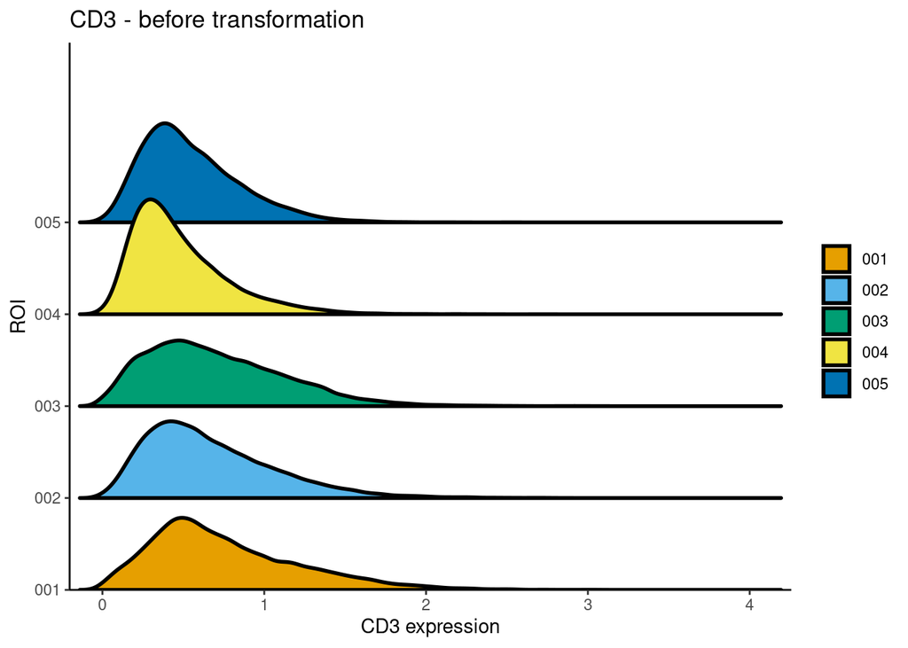

```r
# Add colnames to the spe experiment and add shortened ROI names
colnames(spe) <- paste0(spe$sample_id, "_", spe$ObjectNumber)
spe$ROI <- as.vector(str_extract_all(spe$sample_id, "00[1-5]", simplify=TRUE))

# Plot counts before normalization
dittoRidgePlot(spe, var="CD3", group.by="ROI", assay="counts") +
    ggtitle("CD3 - before transformation")
```

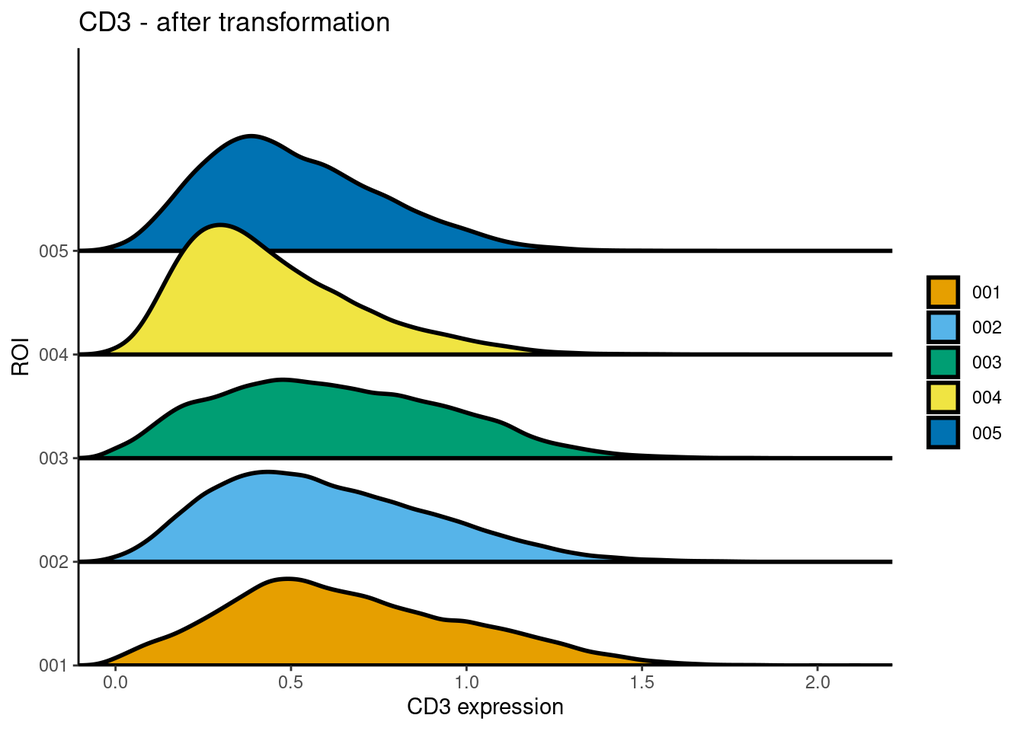

```r
# Normalize counts
assay(spe, "exprs") <- asinh(counts(spe)/1)
# Test log transformation
assay(spe, "log_exprs") <- log(counts(spe) + 0.1)

# Plot counts after normalization
dittoRidgePlot(spe, var="CD3", group.by="ROI", assay="exprs") +
    ggtitle("CD3 - after transformation")
```

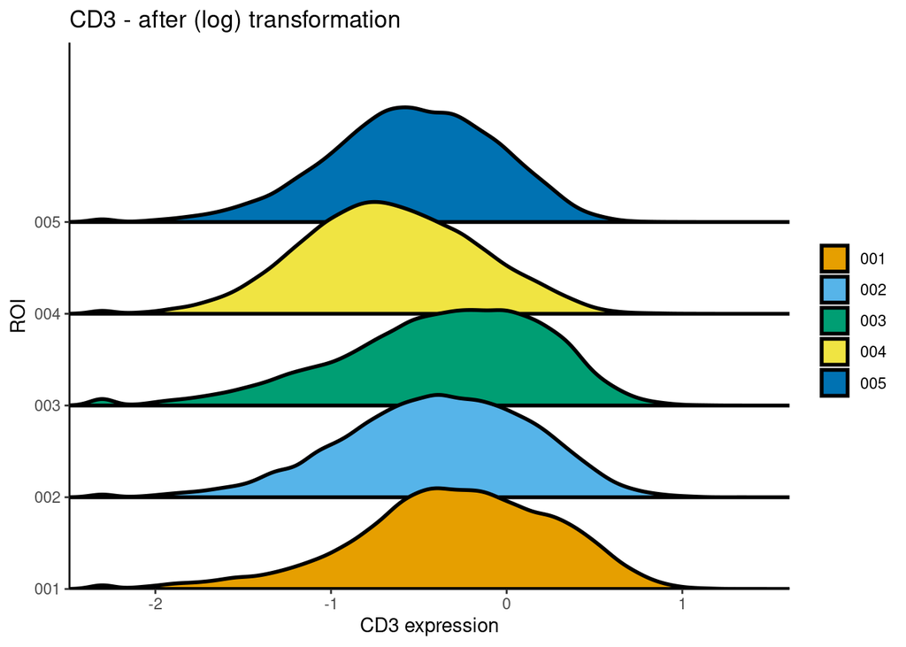

```r
# Plot counts after (log) normalization
dittoRidgePlot(spe, var="CD3", group.by="ROI", assay="log_exprs") +
    ggtitle("CD3 - after (log) transformation")
```

```r
# Define channels of interest (so far all channels are kept)
# rowData(spe)$use_channel <- !grepl("DNA|Histone", rownames(spe))
rowData(spe)$use_channel <- rep(TRUE, length(rownames(spe)))
```

Next, if parameter correct_spillover is set to TRUE, we read in the spillover matrix and do spillover correction.

```r
if (correct_spillover){
  # Read in spillover matrix
  sm <- readRDS(sm.path)
  # Read in isotope_list from CATALYST needed for spillover correction
  isotope_list <- CATALYST::isotope_list
  isotope_list$Ar <- 80

  # Create column in rowData named channel name carrying channel names according to
  # CATALYST standards
  rowData(spe)$channel_name <- paste0(rowData(spe)$channel, "Di")

  # Adapt spillover matrix to only contain isotopes used in our experiment
  adapted_sm <- adaptSpillmat(sm, rowData(spe)$channel_name,
                              isotope_list=isotope_list)
  # Add to our SPE
  metadata(spe)$spillover_matrix <- adapted_sm

  # Perform spillover correction for counts and asinh transformed counts
  spe <- compCytof(spe, adapted_sm, transform=FALSE, isotope_list=isotope_list,
                   overwrite=FALSE, cofactor=1)
  spe <- compCytof(spe, adapted_sm, transform=TRUE, cofactor=1,
                   isotope_list=isotope_list, overwrite=FALSE)
}
```

Before we continue with the image preprocessing, we save the SpatialExperiment as a python Anndata object (.h5ad).

```r
# Save RDS files
# saveRDS(spe, file.path(out.path, "spe.rds"))
# saveRDS(images, file.path(out.path, "images.rds"))
# saveRDS(masks, file.path(out.path, "masks.rds"))

if (correct_spillover){
  # Write SpatialExperiment to Anndata for use in python
  writeH5AD(SingleCellExperiment(list(counts=assay(spe, "counts"),
                                      exprs=assay(spe, "exprs"),
                                      log_exprs=assay(spe, "log_exprs"),
                                      compcounts=assay(spe, "compcounts"),
                                      compexprs=assay(spe, "compexprs")),
                                 colData=colData(spe),
                                 rowData=rowData(spe)), file=file.path(out.path, "spe.h5ad"))
} else {
  # Write SpatialExperiment to Anndata for use in python
  writeH5AD(SingleCellExperiment(list(counts=assay(spe, "counts"),
                                      exprs=assay(spe, "exprs"),
                                      log_exprs=assay(spe, "log_exprs")),
                                 colData=colData(spe),
                                 rowData=rowData(spe)), file=file.path(out.path, "composite_measurements.h5ad"))
}
```

```
## ℹ Using the 'counts' assay as the X matrix
```

### Image preprocessing

Next, we load the images and masks generated by steinbock and do the image preprocessing by correcting for channel spillover if the corresponding parameter is set.

```r
# Load TIFF images and masks
images <- loadImages(images.path)
```

```
## All files in the provided location will be read in.
```

```r
masks <- loadImages(masks.path, as.is=TRUE)
```

```
## All files in the provided location will be read in.
```

```r
# Add channel names to the images
channelNames(images) <- rownames(spe)
images
```

```
## CytoImageList containing 5 image(s)
## names(5): 20221108_TsH_LSS_cisiabmix2_179_001 20221108_TsH_LSS_cisiabmix2_179_002 20221108_TsH_LSS_cisiabmix2_179_003 20221108_TsH_LSS_cisiabmix2_179_004 20221108_TsH_LSS_cisiabmix2_179_005
## Each image contains 16 channel(s)
## channelNames(16): SMA CC0_panCK_Ki-67 CD3 CC1_CD4 CC2_SMA_CD20 CD20 CC3_CD3 CC4_CD11c CC5_Ki-67_CD8a CD8a CD11c CD4 panCK 191Ir 193Ir Ki-67
```

```r
# Check that images and masks have the same name and are in the same order
# for downstream analysis
assert("Check that images and masks have the same name and are in the same order.",
       all.equal(names(images), names(masks)))

# Add metadata to the images
ROI <- str_extract_all(names(images), "00[1-5]", simplify=TRUE)
mcols(images) <- mcols(masks) <- DataFrame(sample_id=names(images),
                                           ROI=ROI)
```

Next, we compute spillover correction on images.

```r
if (correct_spillover){
  # Change channel names to match CATALYST
  channelNames(images) <- rowData(spe)$channel_name

  # Compute channel spillover on images
  images_comp <- compImage(images, adapted_sm, BPPARAM=MulticoreParam())
  # Rename channels to original names
  channelNames(images_comp) <- rownames(spe)
}
```

And we save the corrected images in the “comp_img” folder (again only if corresponding parameter is set).

```r
if (correct_spillover){
  # Create output directory for images
  dir.create(file.path(out.path, "comp_img"))

  # Save spillover corrected images to above defined output directory
  lapply(names(images_comp), function(x){
    writeImage(as.array(images_comp[[x]])/(2^16 - 1),
               paste0(out.path, "/comp_img/", x, ".tiff"),
               bits.per.sample=16)
  })
}
```

## Quality Control (code not run in HTML)

The next part will go over some QC as shown in the *IMCPipeline tutorial*. This code will not be run in the HTML output script since it creates a lot of plots, which should be interactively looked at once before continuing with any further analysis.

### Colour scheme

First, we define a colour scheme to be used in plots.

```r
# Create list which contains colour schemes for ROI and sample_id (the same in
# our case)
color_vectors <- list()

# Create named colour schemes
ROI <- setNames(brewer.pal(length(unique(spe$ROI)), name="BrBG"),
                unique(spe$ROI))
sample_id <- setNames(dittoColors(reps=1)[seq_along(unique(spe$sample_id))],
                unique(spe$sample_id))

# Add colour schemes to empty color_vectors list
color_vectors$ROI <- ROI
color_vectors$sample_id <- sample_id

# Add colour scheme as metadata of our spe experiment
metadata(spe)$color_vectors <- color_vectors
```

### Image QC

Next, we perform image- and channel-wise normalization and do some QC checks on the images.

```r
# Set a seed for reproducibility
set.seed(20220118)

# Get image indexes (originally only some of the images are selected, but here we
# do select all of them )
# img_ids <- sample(seq_len(length(images)), 3)
img_ids <- seq_len(length(images))

# Normalize and clip images
cur_images <- images[img_ids]
cur_images <- normalize(cur_images, separateImages=TRUE)
cur_images <- normalize(cur_images, inputRange=c(0, 0.2))

# Overlay segmentation masks on images and displaying channels that were used
# for segmentation (only for the first image here) for a QC check
plotPixels(cur_images,
           mask=masks,
           img_id="sample_id",
           missing_colour="white",
           colour_by=c("CD20", "panCK", "SMA", "191Ir"),
           colour=list(CD20=c("black", "red"),
                       panCK=c("black", "green"),
                       SMA=c("black", "cyan"),
                       "191Ir"=c("black", "blue")),
           image_title=NULL,
           legend=list(colour_by.title.cex=0.7,
                       colour_by.labels.cex=0.7))

# Sample 2000 cells for another QC check
cur_cells <- sample(seq_len(ncol(spe)), 2000)

# Visualize single-cell expression in form of a heatmap for another QC check
dittoHeatmap(spe[, cur_cells], genes=rownames(spe)[rowData(spe)$use_channel],
             assay="exprs", cluster_cols=TRUE, scale="none",
             heatmap.colors=viridis(100),
             annot.by="ROI",
             annotation_colors=list(ROI=metadata(spe)$color_vectors$ROI)
             )
```

Next, we perform image level QC by looking at the signal-to-noise ratio (SNR) for individual channels and markers, the image area covered by cells and mean marker expression per ROI.

```r
# Calculate signal-to-noise ratio using the otsu thresholding approach
cur_snr <- lapply(images, function(img){
    mat <- apply(img, 3, function(ch){
        # Otsu threshold
        thres <- otsu(ch, range=c(min(ch), max(ch)))
        # Signal-to-noise ratio
        snr <- mean(ch[ch > thres]) / mean(ch[ch <= thres])
        # Signal intensity
        ps <- mean(ch[ch > thres])

        return(c(snr=snr, ps=ps))
    })
    t(mat) %>% as.data.frame() %>%
        mutate(marker=colnames(mat)) %>%
        pivot_longer(cols=c(snr, ps))
})

cur_snr <- do.call(rbind, cur_snr)

# Plot signal-to-noise-ratio vs signal intensity
cur_snr %>%
    group_by(marker, name) %>%
    summarize(mean=mean(value),
              ci=qnorm(0.975)*sd(value)/sqrt(n())) %>%
    pivot_wider(names_from=name, values_from=c(mean, ci)) %>%
    ggplot() +
#    geom_errorbar(aes(y=log2(mean_snr), xmin=log2(mean_ps - ci_ps),
#                      xmax=log2(mean_ps + ci_ps))) +
#    geom_errorbar(aes(x=log2(mean_ps), ymin=log2(mean_snr - ci_snr),
#                      ymax=log2(mean_snr + ci_snr))) +
    geom_point(aes(log2(mean_ps), log2(mean_snr))) +
    geom_label_repel(aes(log2(mean_ps), log2(mean_snr), label=marker), max.overlaps=Inf) +
    theme_minimal(base_size=15) + ylab("Signal-to-noise ratio") +
    xlab("Signal intensity")
```

```r
# Plot image area covered by cells
colData(spe) %>%
    as.data.frame() %>%
    group_by(sample_id) %>%
    summarize(cell_area=sum(area),
           no_pixels=mean(width_px) * mean(height_px)) %>%
    mutate(covered_area=cell_area / no_pixels) %>%
    ggplot() +
        geom_point(aes(sample_id, covered_area)) +
        theme_minimal(base_size=15) +
        ylim(c(0, 1)) +
        theme(axis.text.x=element_text(angle=90, hjust=1, size=8)) +
        ylab("% covered area") + xlab("")
```

```r
# Compute image/ROI mean and transform intensities
image_mean <- aggregateAcrossCells(spe,
                                   ids=spe$sample_id,
                                   statistics="mean",
                                   use.assay.type="counts")
assay(image_mean, "exprs") <- asinh(counts(image_mean))

# Plot mean marker expression per ROI
dittoHeatmap(image_mean, genes=rownames(spe)[rowData(spe)$use_channel],
             assay="exprs", cluster_cols=TRUE, scale="none",
             heatmap.colors=viridis(100),
             annot.by=c("ROI"),
             annotation_colors=list(ROI=metadata(spe)$color_vectors$ROI),
             show_colnames=TRUE)
```

### Singel Cell QC

Now, we perform single cell level QC by looking at the signal-to-noise ratio (SNR) for individual channels and markers, cell sizes across images/ROIs, image area covered by cells, check for potential staining differences and mean marker expression per ROI.

```r
# Set seed for reproducibility
set.seed(220224)

# To assess the snr, a two component Gaussian mixture model for each marker
# is derived to find cells with positive and negative expression (signal/noise)
mat <- apply(assay(spe, "exprs"), 1, function(x){
    cur_model <- Mclust(x, G=2)
    mean1 <- mean(x[cur_model$classification == 1])
    mean2 <- mean(x[cur_model$classification == 2])

    signal <- ifelse(mean1 > mean2, mean1, mean2)
    noise <- ifelse(mean1 > mean2, mean2, mean1)

    return(c(snr=signal/noise, ps=signal))
})

cur_snr <- t(mat) %>% as.data.frame() %>%
        mutate(marker=colnames(mat))

# Plot signal-to-noise ratio vs signal intensity
cur_snr %>% ggplot() +
    geom_point(aes(log2(ps), log2(snr))) +
    geom_label_repel(aes(log2(ps), log2(snr), label=marker)) +
    theme_minimal(base_size=15) + ylab("Signal-to-noise ratio") +
    xlab("Signal intensity")
```

```r
# Plot distribution of cell sizes across images
colData(spe) %>%
    as.data.frame() %>%
    group_by(sample_id) %>%
    ggplot() +
        geom_boxplot(aes(sample_id, area)) +
        theme_minimal(base_size=15) +
        theme(axis.text.x=element_text(angle=90, hjust=1, size=8)) +
        ylab("Cell area") + xlab("")
```

```r
# Print summary of cell areas
summary(spe$area)

# Remove very small cells
# sum(spe$area < 5)
# spe <- spe[, spe$area >= 5]
```

```r
# Plot percentage of image area covered by cells
colData(spe) %>%
    as.data.frame() %>%
    group_by(sample_id) %>%
    summarize(cell_count=n(),
           no_pixels=mean(width_px) * mean(height_px)) %>%
    mutate(cells_per_mm2=cell_count/(no_pixels/1000000)) %>%
    ggplot() +
        geom_point(aes(sample_id, cells_per_mm2)) +
        theme_minimal(base_size=15)  +
        theme(axis.text.x=element_text(angle=90, hjust=1, size=8)) +
        ylab("Cells per mm2") + xlab("")
```

```r
# Check for potential staining differences using ridgeline visualizations
multi_dittoPlot(spe, vars=rownames(spe)[rowData(spe)$use_channel],
               group.by="ROI", plots=c("ridgeplot"),
               assay="exprs",
               color.panel=metadata(spe)$color_vectors$ROI,
               ncol=5)
```